# 9.2(b): Multiple coins from a single mint

## Introduction

This is the second of three models in Section 9.2 of Kruschke. It makes a weak claim about the value of $\omega$, but a strong dependence of $\theta$ on $\omega$.

## Preliminaries

Load necessary packages:

```r
library(rstan)
library(shinystan)
library(bayesplot)
```

Set Stan to save compiled code.

```r
rstan_options(auto_write = TRUE)
```

Set Stan to use parallel processing where possible.

```r
options(mc.cores = parallel::detectCores())
```

## Data

```r
S <- 2 # 2 coins
N1 <- 15
N2 <- 5
N <- c(N1, N2)
y1 <- 3 # 3 heads (of 15)
y2 <- 4 # 4 heads (of 5)
y <- c(y1, y2)
stan_data <- list(S = S, N = N, y = y)
```

## Stan code

The only thing different here are the values of $A_{\omega}$, $B_{\omega}$, and $K$.

```stan
data {
    int<lower = 0> S;
    int<lower = 0> N[S];
    int<lower = 0> y[S];
}
transformed data {
    real<lower = 0> A_omega;
    real<lower = 0> B_omega;
    real<lower = 0> K;

    A_omega = 2;
    B_omega = 2;
    K = 75;
}
parameters {
    real<lower = 0, upper = 1> omega;
    real<lower = 0, upper = 1> theta[S];
}
transformed parameters {
    real<lower = 0> a;
    real<lower = 0> b;

    a = omega * (K - 2) + 1;
    b = (1 - omega) * (K - 2) + 1;
}
model {
    omega ~ beta(A_omega, B_omega);
    theta ~ beta(a, b);
    y ~ binomial(N, theta);
}
generated quantities {
    int<lower = 0> y_rep[S];

    for (s in 1:S) {
        y_rep[s] = binomial_rng(N[s], theta[s]);
    }
}
```

## Sampling from the model

```r
set.seed(11111)
fit_mcsmb <- sampling(mcsmb, data = stan_data, refresh = 0)
```

## Diagnosing the model

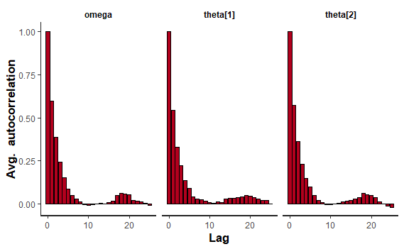

```r
plot(fit_mcsmb, plotfun = "ac", pars = c("omega", "theta"))
```

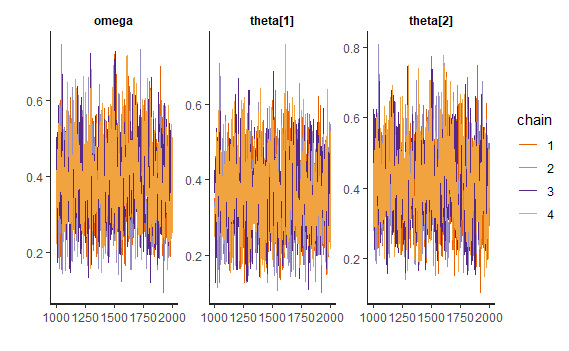

```r
plot(fit_mcsmb, plotfun = "trace",
     pars = c("omega", "theta"))
```

## Summarizing the model

```r
fit_mcsmb
```

```
Inference for Stan model: stan-30b869091fa1.
4 chains, each with iter=2000; warmup=1000; thin=1;
post-warmup draws per chain=1000, total post-warmup draws=4000.

           mean se_mean   sd   2.5%    25%    50%    75%  97.5%
omega      0.39    0.00 0.10   0.19   0.31   0.38   0.46   0.60
theta[1]   0.36    0.00 0.10   0.18   0.29   0.35   0.42   0.56
theta[2]   0.42    0.00 0.11   0.21   0.34   0.41   0.49   0.64
a         29.32    0.25 7.66  15.12  23.94  28.85  34.30  45.08
b         45.68    0.25 7.66  29.92  40.70  46.15  51.06  59.88
y_rep[1]   5.37    0.05 2.29   1.00   4.00   5.00   7.00  10.00
y_rep[2]   2.06    0.02 1.19   0.00   1.00   2.00   3.00   4.00
lp__     -16.09    0.03 1.25 -19.26 -16.66 -15.76 -15.18 -14.67
         n_eff Rhat
omega      962    1
theta[1]   940    1
theta[2]   972    1
a          962    1
b          962    1
y_rep[1]  1802    1
y_rep[2]  2747    1
lp__      1391    1

Samples were drawn using NUTS(diag_e) at Sun May 26 15:50:24 2019.
For each parameter, n_eff is a crude measure of effective sample size,
and Rhat is the potential scale reduction factor on split chains (at
convergence, Rhat=1).
```

## Visualizing the model

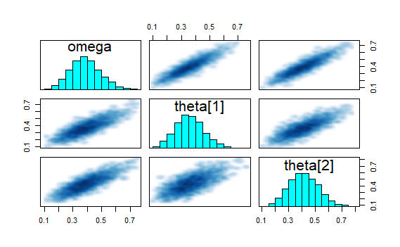

```r
pairs(fit_mcsmb, pars = c("omega", "theta"))
```

```
ci_level: 0.8 (80% intervals)
outer_level: 0.95 (95% intervals)
```

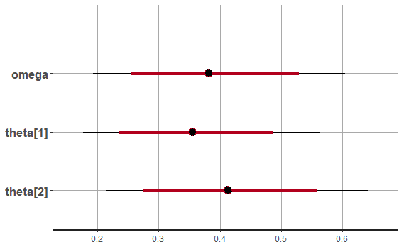

```r
plot(fit_mcsmb, pars = c("omega", "theta"))
```

With a much larger value of $K$, the values of $\theta$ are much more constrained to follow the value of $\omega$ from the prior.

## Examining the prior

```stan
data {
    int<lower = 0> S;
    int<lower = 0> N[S];
    int<lower = 0> y[S];
}
transformed data {
    real<lower = 0> A_omega;
    real<lower = 0> B_omega;
    real<lower = 0> K;

    A_omega = 2;
    B_omega = 2;
    K = 75;
}
parameters {
    real<lower = 0, upper = 1> omega;
    real<lower = 0, upper = 1> theta[S];
}
transformed parameters {
    real<lower = 0> a;
    real<lower = 0> b;

    a = omega * (K - 2) + 1;
    b = (1 - omega) * (K - 2) + 1;
}
model {
    omega ~ beta(A_omega, B_omega);
    theta ~ beta(a, b);
//    y ~ binomial(N, theta);
}
```

```r
set.seed(11111)
fit_mcsmb_prior <- sampling(mcsmb_prior, data = stan_data, refresh = 0)
```

```r
fit_mcsmb_prior
```

```
Inference for Stan model: stan-30b857da1516.
4 chains, each with iter=2000; warmup=1000; thin=1;
post-warmup draws per chain=1000, total post-warmup draws=4000.

          mean se_mean    sd  2.5%   25%   50%   75% 97.5% n_eff
omega     0.50    0.01  0.23  0.09  0.32  0.50  0.68  0.91   603
theta[1]  0.50    0.01  0.23  0.09  0.32  0.50  0.68  0.91   607
theta[2]  0.50    0.01  0.23  0.09  0.32  0.50  0.69  0.91   600
a        37.48    0.68 16.77  7.87 24.46 37.30 50.56 67.51   603
b        37.52    0.68 16.77  7.49 24.44 37.70 50.54 67.13   603
lp__     -3.55    0.05  1.53 -7.38 -4.23 -3.18 -2.45 -1.82   865
         Rhat
omega       1
theta[1]    1
theta[2]    1
a           1
b           1
lp__        1

Samples were drawn using NUTS(diag_e) at Sun May 26 15:52:01 2019.
For each parameter, n_eff is a crude measure of effective sample size,
and Rhat is the potential scale reduction factor on split chains (at
convergence, Rhat=1).
```

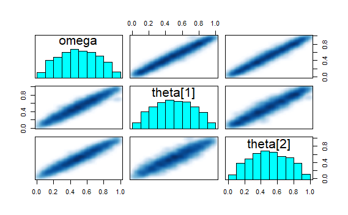

```r
pairs(fit_mcsmb_prior, pars = c("omega", "theta"))
```

```
ci_level: 0.8 (80% intervals)
outer_level: 0.95 (95% intervals)
```

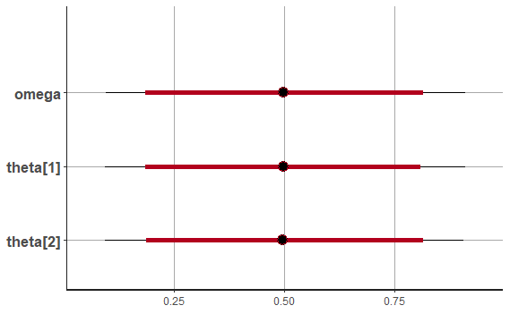

```r
plot(fit_mcsmb_prior, pars = c("omega", "theta"))
```

## Posterior predictive check

Extract predicted values:

```r
samples_mcsmb <- extract(fit_mcsmb)
y_rep <- samples_mcsmb$y_rep
```

Graph values of $y$ against summaries of $y_{rep}$.

(The `ppc_stat` function requires a matrix as input, so we have to convert the single columns of values in `y_rep[, 1]` to a 4000 by 1 matrix.)

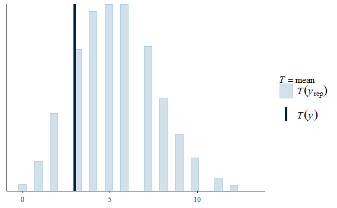

```r
ppc_stat(y[1], as.matrix(y_rep[ , 1]))
```

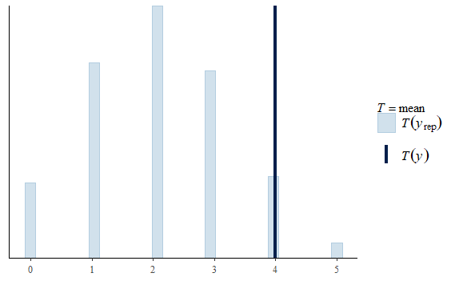

```r
ppc_stat(y[2], as.matrix(y_rep[ , 2]))
```

The $x$ value in the graph below simply identifies the two coins.

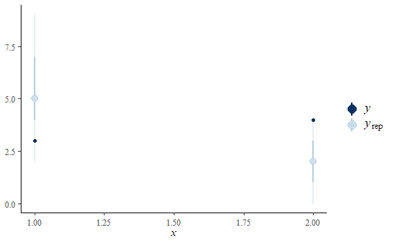

```r
ppc_intervals(y, y_rep)
```

## ShinyStan

Run the following code from the Console:

```
launch_shinystan(fit_mcsmb)
```